# An overview of machine learning problems

Vladan Devedzic

## (Installing and) Loading the required R packages

```r
# install.packages('corrplot')
library(corrplot)
library(ggplot2)
```

## Linear regression

### Reading the dataset

A modified or newly created dataset might have been saved earlier using:  
`write.csv(x = <dataframe>, file = "<filename>", row.names = F) # do not include the row names (row numbers) column`  
`saveRDS(object = <dataframe or another R object>, file = "<filename>") # save R object for the next session`  
Restoring the dataset from the corresponding RData file:  
`<dataframe or another R object> <- readRDS(file = "<filename>") # restore R object in the next session`  
`The Beatles songs dataset has been saved earlier using:`  
# saveRDS(the.beatles.songs, “The Beatles songs dataset, v2.1.RData”)

```r
the.beatles.songs <- readRDS("The Beatles songs dataset, v2.1.RData")
summary(the.beatles.songs)
```

```
##     Title                Year       Duration     Other.releases
##  Length:310         1963   :67   Min.   : 23.0   Min.   : 0.00
##  Class :character   1968   :45   1st Qu.:133.0   1st Qu.: 0.00
##  Mode  :character   1969   :42   Median :148.0   Median : 9.00
##                     1964   :41   Mean   :159.9   Mean   :10.42
##                     1965   :37   3rd Qu.:174.0   3rd Qu.:16.00
##                     1967   :27   Max.   :502.0   Max.   :56.00
##                     (Other):51
##  Top.50.Billboard
##  Min.   : 0.000
##  1st Qu.: 0.000
##  Median : 0.000
##  Mean   : 4.061
##  3rd Qu.: 0.000
##  Max.   :50.000
##
```

## Examining the data

### Scatterplot matrices

Scatterplot matrices are uuseful for examining the presence of linear relationship between several pairs of variables:  
`pairs(~<x1> + <x2> + ..., data = <dataframe>)`

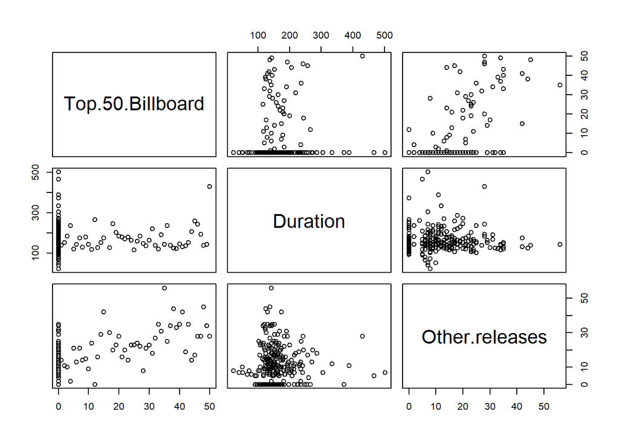

```r
pairs(~Top.50.Billboard + Duration + Other.releases, data = the.beatles.songs)
```

### Correlation plots

Visual representation of correlations between numeric variables in the dataset: `<numeric dataframe> <- # create all-numeric dataframe,`  
`+ data.frame(<num col 1 name> = <dataframe>$<num col 1>, # leave out all non-numeric columns`  
`+ <num col 2 name> = <dataframe>$<num col 2>, # from the original dataframe`  
`+ ...)`  
`<correlation matrix> <- cor(<numeric dataframe>) # all-numeric dataframe`  
`library(corrplot)`  
`corrplot.mixed(<correlation matrix>, tl.cex = <text font size>, number.cex = <number font size>)`

```r
the.beatles.songs.num <- data.frame(Top.50.Billboard = the.beatles.songs$Top.50.Billboard,
                                    Duration = the.beatles.songs$Duration,
                                    Other.releases = the.beatles.songs$Other.releases)
correlation.matrix <- cor(the.beatles.songs.num)
correlation.matrix
```

```
##                  Top.50.Billboard   Duration Other.releases
## Top.50.Billboard        1.0000000 0.12050340     0.61325609
## Duration                0.1205034 1.00000000     0.02617334
## Other.releases          0.6132561 0.02617334     1.00000000
```

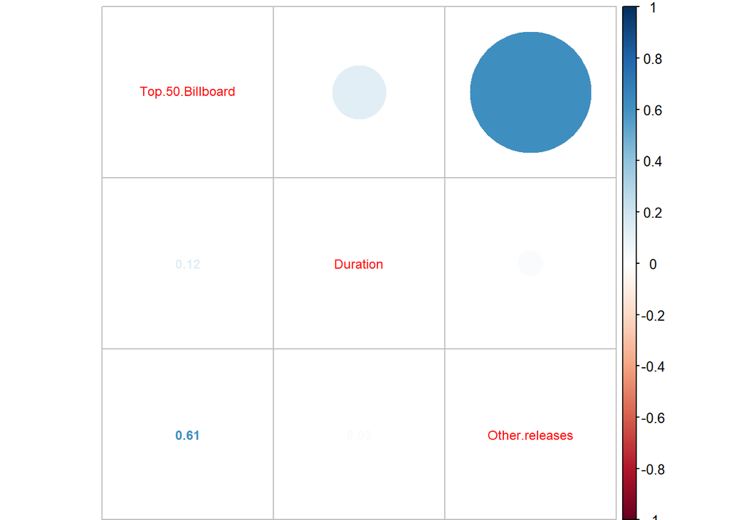

```r
library(corrplot)
corrplot.mixed(correlation.matrix, tl.cex = 0.75, number.cex = 0.75)
```

### Scatterplots in ggplot2

`ggplot(<dataset>, aes(x = <num.var.1>, y = <num.var.2>)) +`  
`+ geom_point(shape = <n>, # <n> = 1: hollow circle`  
`+ fill = <color 1>, # color of point fill (optional)`  
`+ color = <color 2>, # color of point line (optional)`  
`+ size = <s>) + # size of point line (optional)`  
`+ geom_smooth(method = lm, # add regression line (optional); if left out, nonlinear best-fit line is shown`  
`+ se=FALSE) # do NOT show 95% confidence region as a shaded area (optional)`

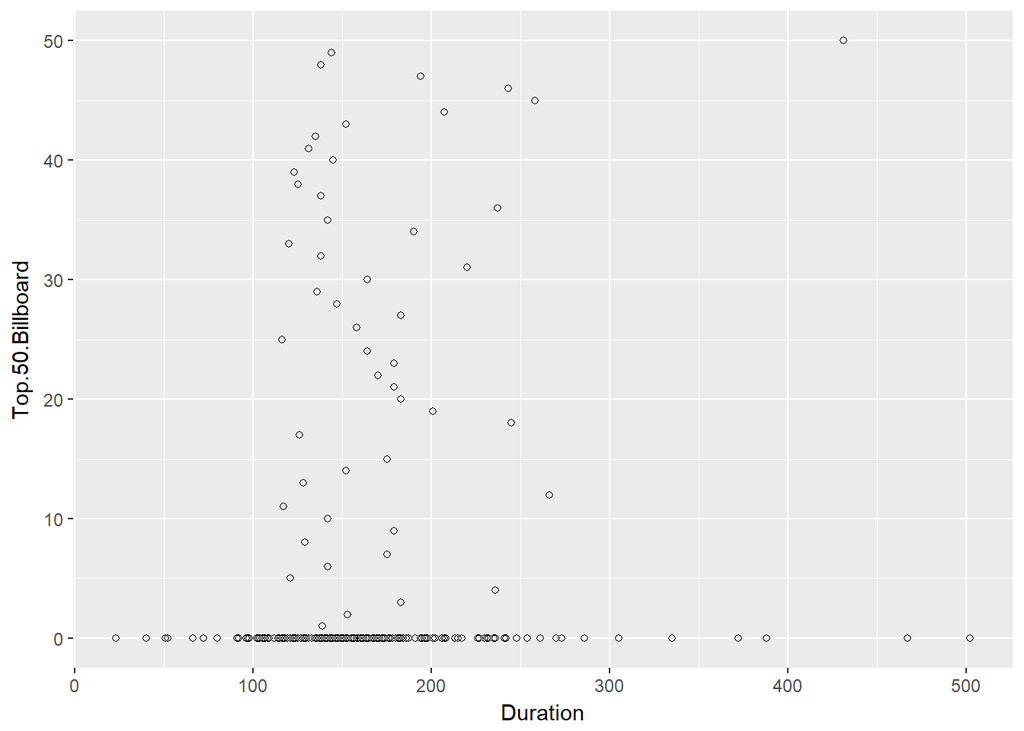

```r
g1 <- ggplot(the.beatles.songs, aes(x = Duration, y = Top.50.Billboard)) +
  geom_point(shape = 1)
g1
```

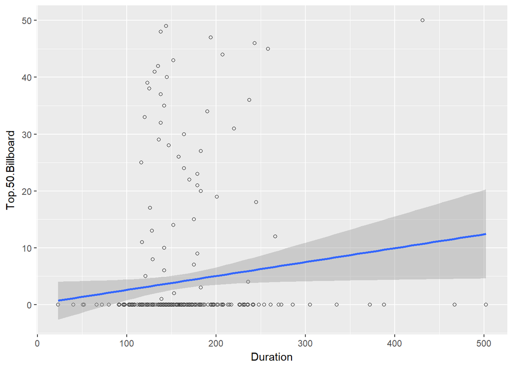

```r
g1 <- ggplot(the.beatles.songs, aes(x = Duration, y = Top.50.Billboard)) +
  geom_point(shape = 1) +
  geom_smooth(method = lm)  # linear regression
g1
```

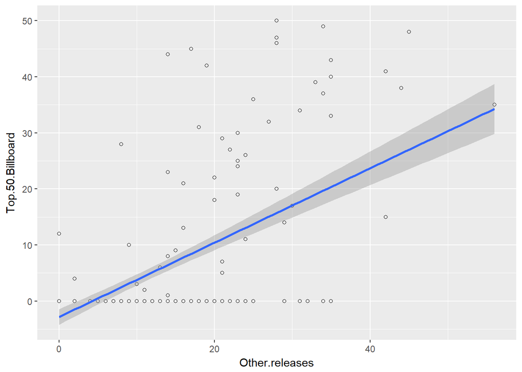

```r
# g1 <- ggplot(the.beatles.songs, aes(x = Duration, y = Top.50.Billboard)) +
#   geom_point(shape = 21, size = 2, fill = "green", color = "red") +
#   geom_smooth(method = lm)
# g1

g2 <- ggplot(the.beatles.songs, aes(x = Other.releases, y = Top.50.Billboard)) +
  geom_point(shape = 1) +
  geom_smooth(method = lm)
g2
```

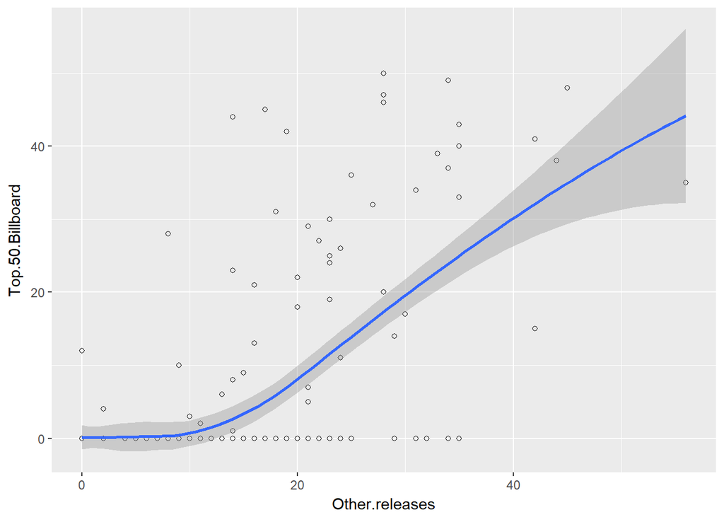

```r
g3 <- ggplot(the.beatles.songs, aes(x = Other.releases, y = Top.50.Billboard)) +
  geom_point(shape = 1) +
  geom_smooth()             # non-linear regression
g3
```

### Build/Fit simple linear regression model and examine it

`<model> <- lm(<y> ~ <x>, # build/fit the model over the <dataset>;`  
`+ data = <dataset>) # <x> and <y> are numeric variables from <dataset>`  
`<model> # show the model`  
`coef(<model>) # show the coefficients of the linear model (intercept and slope)`  
`confint(<model>) # show the confidence intervals for the estimated intercept and slope`  
`summary(<model>) # show the model statistics`

```r
lm.fit <- lm(Top.50.Billboard ~ Other.releases, data = the.beatles.songs)
lm.fit
```

```
##
## Call:
## lm(formula = Top.50.Billboard ~ Other.releases, data = the.beatles.songs)
##
## Coefficients:
##    (Intercept)  Other.releases
##         -2.849           0.663
```

```r
coef(lm.fit)
```

```
##    (Intercept) Other.releases
##     -2.8486751      0.6629803
```

```r
confint(lm.fit)
```

```
##                     2.5 %     97.5 %
## (Intercept)    -4.2436506 -1.4536996
## Other.releases  0.5672378  0.7587228
```

```r
summary(lm.fit)
```

```
##
## Call:
## lm(formula = Top.50.Billboard ~ Other.releases, data = the.beatles.songs)
##
## Residuals:
##     Min      1Q  Median      3Q     Max
## -20.356  -4.444  -1.129   2.849  37.567
##
## Coefficients:
##                Estimate Std. Error t value Pr(>|t|)
## (Intercept)    -2.84868    0.70894  -4.018 7.38e-05 ***
## Other.releases  0.66298    0.04866  13.626  < 2e-16 ***
## ---
## Signif. codes:  0 '***' 0.001 '**' 0.01 '*' 0.05 '.' 0.1 ' ' 1
##
## Residual standard error: 8.722 on 308 degrees of freedom
## Multiple R-squared:  0.3761, Adjusted R-squared:  0.3741
## F-statistic: 185.7 on 1 and 308 DF,  p-value: < 2.2e-16
```

### Make predictions

`predict(<model>, # the model built above`  
`+ <test dataframe>, # data frame built over a (small) vector of <x> to predict <y> for;`  
`+ # in the <test dataframe> the name of <x> as in the original dataframe`  
`+ interval = "confidence" | # include the confidence interval for the predictions (optional)`  
`+ "predict") # include prediction intervals (optional)`

```r
the.beatles.songs.num <- data.frame(Other.releases = c(5, 15, 25))
predict(lm.fit, newdata = the.beatles.songs.num, interval = "confidence")
```

```
##          fit        lwr       upr
## 1  0.4662263 -0.6381845  1.570637
## 2  7.0960291  6.0272679  8.164790
## 3 13.7258319 12.0234503 15.428213
```

```r
predict(lm.fit, newdata = the.beatles.songs.num, interval = "predict")
```

```
##          fit        lwr      upr
## 1  0.4662263 -16.731937 17.66439
## 2  7.0960291 -10.099882 24.29194
## 3 13.7258319  -3.521058 30.97272
```

### Check how well the model fits the data

`par(mfrow = c(2,2)) # set up the plotting panel for 4 graphs`  
`plot(<model>) # plot the 4 graphs`  
`par(mfrow = c(1,1)) # reset the plotting panel`

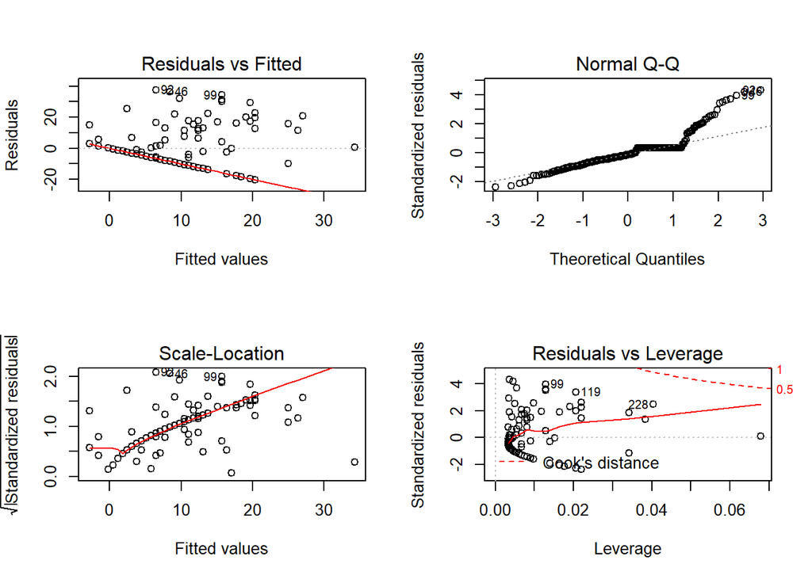

```r
par(mfrow=c(2,2))
plot(lm.fit)
```

```r
par(mfrow = c(1,1))
```

The 4 graphs:

- Residuals vs Fitted: Is linear assumption justified?
  - Can a non-linear pattern be observed in the residuals? If so, there is a non-linearity not explained by the model…
  - Are the residuals more-or-less evenly (randomly) distributed around the horizontal dotted line? It’s better if they are (the linearity assumption is then likely to hold). Ideally (but very unlikely), the red line is overlapped with the horizontal dotted line.
- Q-Q plot: Are the residuals normally distributed (reside on the diagonal line)? It’s good if they are.
- Scale-Location: Is the variance of residuals similar (even) along the fitted line?
  - Are the residuals spread evenly along the range(s) of predictor(s)? It’s good if they are, and in that case the red line is more-or-less horizontal.
- Residuals vs Leverage: Are there extreme values of a predictor (points of high leverage) that shouldn’t be excluded from the analysis?
  - Are there data points outside the dashed red line (having a high Cook’s distance score)? If so, they should be given special attention. If they result from erroneous data, they can be excluded from the analysis. Otherwise, they shouldn’t be excluded from the analysis, because R-squared and the slope will change a lot. In that case, linear regression is not applicable.

The four plots show potential problematic cases with the row numbers of the data in the dataset. If some cases are identified across all four plots (Residuals vs Leverage being especially critical), or at least on all plots other than Q-Q plot, it is a good idea to take a closer look at them individually. Is there anything special for the subject? Or could they be simply errors in data entry?

## Classification - decision trees

### Reading the dataset

The dataset has been prepared earlier and saved using:  
`saveRDS(the.beatles.songs, "The Beatles songs dataset, v2.2.RData")`  
Read the dataset using:  
`<dataframe or another R object> <- readRDS(file = "<filename>") # restore R object / dataset`

```r
the.beatles.songs <- readRDS("The Beatles songs dataset, v2.2.RData")
summary(the.beatles.songs)
```

```
##     Title                Year       Duration     Other.releases
##  Length:310         1963   :66   Min.   : 23.0   Min.   : 0.00
##  Class :character   1968   :45   1st Qu.:133.0   1st Qu.: 0.00
##  Mode  :character   1969   :43   Median :150.0   Median : 9.00
##                     1964   :41   Mean   :159.6   Mean   :10.42
##                     1965   :37   3rd Qu.:172.8   3rd Qu.:16.00
##                     1967   :27   Max.   :502.0   Max.   :56.00
##                     (Other):51
##             Single.certification   Covered.by     Top.50.Billboard
##  No                   :259       Min.   : 0.000   Min.   : 0.000
##  RIAA 2xPlatinum      :  6       1st Qu.: 0.000   1st Qu.: 0.000
##  RIAA 4xPlatinum      :  2       Median : 2.000   Median : 0.000
##  RIAA Gold            : 33       Mean   : 6.752   Mean   : 4.061
##  RIAA Gold, BPI Silver:  2       3rd Qu.: 8.000   3rd Qu.: 0.000
##  RIAA Platinum        :  8       Max.   :70.000   Max.   :50.000
##
##  Top.50
##  No :261
##  Yes: 49
##
##
##
##
##
```

### Examining the distribution of the output values

`table(<dataset>$<output variable>)`  
`prop.table(table(<dataset>$<output variable>))`  
`round(prop.table(table(<dataset>$<output variable>)), digits = 2)`

```r
table(the.beatles.songs$Top.50)
```

```
##
##  No Yes
## 261  49
```

```r
prop.table(table(the.beatles.songs$Top.50))
```

```
##
##        No       Yes
## 0.8419355 0.1580645
```

```r
round(prop.table(table(the.beatles.songs$Top.50)), digits = 2)
```

```
##
##   No  Yes
## 0.84 0.16
```

### Train and test datasets

`install.packages("caret")`  
`library(caret)`  
`set.seed(<n>)`  
`<train dataset indices> <- # stratified partitioning:`  
`+ createDataPartition(<dataset>$<output variable>, # the same distribution of the output variable in both sets`  
`+ p = .80, # 80/20% of data in train/test sets`  
`+ list = FALSE) # don't make a list of results, make a matrix`  
`<train dataset> <- <dataset>[<train dataset indices>, ]`  
`<test dataset> <- <dataset>[-<train dataset indices>, ]`

```r
library(caret)
set.seed(333)
train.data.indices <- createDataPartition(the.beatles.songs$Top.50, p = 0.80, list = FALSE)
train.data <- the.beatles.songs[train.data.indices, ]
test.data <- the.beatles.songs[-train.data.indices, ]
```

### Building the model / decision tree

`# install.packages("rpart")`  
`library(rpart)`  
`<decision tree> <- rpart(<output variable> ~ # build the tree`  
`+ <predictor variable 1> + <predictor variable 2> + ..., # . to include all variables`  
`+ data = <train dataset>,`  
`+ method = "class") # build classification tree`

```r
library(rpart)
top.50.tree <- rpart(Top.50 ~ Single.certification + Covered.by + Year,
                     data = train.data,
                     method = "class")
```

### Depicting the model

`# install.packages('rattle')`  
`# install.packages('rpart.plot')`  
`# install.packages('RColorBrewer')`  
`library(rpart)`  
`library(rattle)`  
`library(rpart.plot)`  
`library(RColorBrewer)`  
`fancyRpartPlot(<decision tree>)`

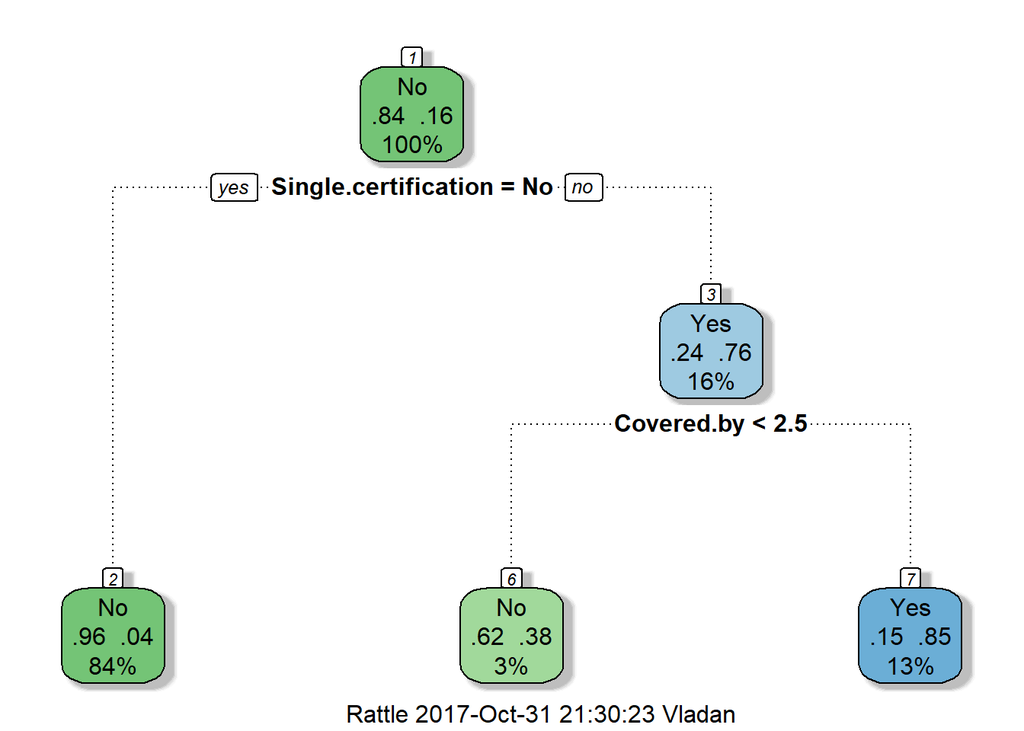

```r
library(rpart)
library(rattle)
library(rpart.plot)
library(RColorBrewer)
fancyRpartPlot(top.50.tree)
```

### Making predictions

`<predictions> <- predict(object = <decision tree>,`  
`+ newdata = <test dataset>,`  
`+ type = "class")`  
`<predictions>[<i1>:<ik>] # examine some of the predictions`  
`<predictions dataframe> <-`  
`+ data.frame(<observation ID> = <test dataset>$<observation ID column>,`  
`+ <another relevant feature> = <test dataset>$<another relevant feature column>,`  
`+ ...,`  
`+ <predictions feature> = <predictions>)`  
`View(<predictions dataframe>)`

```r
top.50.predictions <- predict(top.50.tree, newdata = test.data, type = "class")
top.50.predictions[1:20]
```

```
##   1   6  22  26  29  32  35  37  44  45  47  50  52  54  65  70  71  72
##  No  No Yes  No  No  No Yes  No  No  No  No Yes  No  No  No  No  No  No
##  76 101
##  No  No
## Levels: No Yes
```

```r
top.50.predictions.dataframe <- data.frame(Song = test.data$Title,
                                           Top.50.Billboard = test.data$Top.50.Billboard,
                                           Top.50 = test.data$Top.50,
                                           Prediction = top.50.predictions)
```

```r
View(top.50.predictions.dataframe)
```

## Clustering - K-Means

### Reading the dataset

The dataset has been prepared earlier and saved using:  
`saveRDS(the.beatles.songs, "The Beatles songs dataset, v2.3.RData")`  
Read the dataset using: `<dataframe or another R object> <- readRDS(file = "<filename>") # restore R object / dataset`

```r
the.beatles.songs <- readRDS("The Beatles songs dataset, v2.3.RData")
summary(the.beatles.songs)
```

```
##     Title              Duration     Other.releases    Covered.by
##  Length:310         Min.   : 23.0   Min.   : 0.00   Min.   : 0.000
##  Class :character   1st Qu.:133.0   1st Qu.: 0.00   1st Qu.: 0.000
##  Mode  :character   Median :150.0   Median : 9.00   Median : 2.000
##                     Mean   :159.6   Mean   :10.42   Mean   : 6.752
##                     3rd Qu.:172.8   3rd Qu.:16.00   3rd Qu.: 8.000
##                     Max.   :502.0   Max.   :56.00   Max.   :70.000
##  Top.50.Billboard
##  Min.   : 0.000
##  1st Qu.: 0.000
##  Median : 0.000
##  Mean   : 4.061
##  3rd Qu.: 0.000
##  Max.   :50.000
```

### Changing the row names

Optional, run in order to focus on numeric variables in the dataset only (for applying K-Means):

```r
rownames(the.beatles.songs) <- the.beatles.songs$Title
the.beatles.songs$Title <- NULL                                     # no longer necessary
```

### Examining the data

See if there are some patterns in the data, pairwise, to possibly indicate clusters:  
`pairs(~ <column 1 name> + <column 2 name> + ..., data = <dataframe>)`

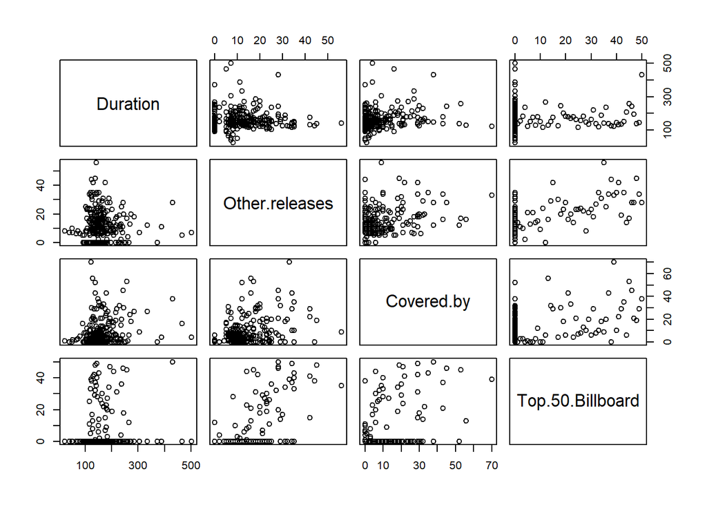

```r
pairs(~ Duration + Other.releases + Covered.by + Top.50.Billboard,  # no any striking pattern, i.e.
      the.beatles.songs)                                            # no visual indication of clusters
```

### K-Means with 2 variables

Plot the data first:  
`<scatterplot> <-`  
`+ ggplot(<dataset>, aes(x = <num.var.1>, y = <num.var.2>)) +`  
`+ geom_point(shape = <n>, # <n> = 1: hollow circle, no fill; <n> = 21: circle that can be filled`  
`+ fill = <color 1>, # color of point fill (optional)`  
`+ color = <color 2>, # color of point line (optional)`  
`+ size = <s>) # size of point line (optional)`  
`<scatterplot> <- <scatterplot> + xlab("<x label>") # label/caption on x-axis`  
`<scatterplot> <- <scatterplot> + ylab("<y label>") # label/caption on x-axis`  
`<scatterplot> <- <scatterplot> + ggtitle("<scatterplot title>") # scatterplot title`

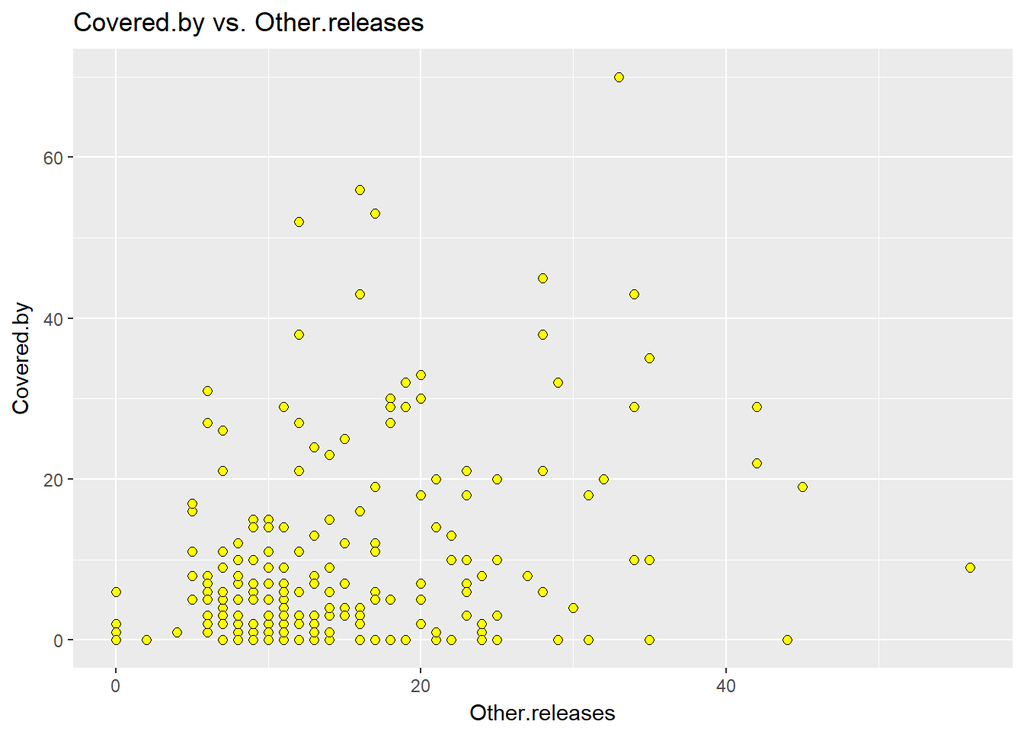

```r
scatterplot1 <- ggplot(the.beatles.songs, aes(x = Other.releases, y = Covered.by))
scatterplot1 <- scatterplot1 + geom_point(shape = 21, fill = "yellow", size = 2)
scatterplot1 <- scatterplot1 + xlab("Other.releases")
scatterplot1 <- scatterplot1 + ylab("Covered.by")
scatterplot1 <- scatterplot1 + ggtitle("Covered.by vs. Other.releases")
scatterplot1
```

Subset the original data to include only the variables to be used in K-Means:  
`<new dataframe> <- subset(<dataframe>[, c("<col1 name>", "<col2 name>")])`  
`<new dataframe> <- subset(<dataframe>[, <col1 index>:<col2 index>)])`

```r
the.beatles.songs.2 <- subset(the.beatles.songs[, c("Other.releases", "Covered.by")])
summary(the.beatles.songs.2)
```

```
##  Other.releases    Covered.by
##  Min.   : 0.00   Min.   : 0.000
##  1st Qu.: 0.00   1st Qu.: 0.000
##  Median : 9.00   Median : 2.000
##  Mean   :10.42   Mean   : 6.752
##  3rd Qu.:16.00   3rd Qu.: 8.000
##  Max.   :56.00   Max.   :70.000
```

```r
head(the.beatles.songs.2)
```

```
##                            Other.releases Covered.by
## 12-Bar Original                         0          0
## A Day in the Life                      12         27
## A Hard Day's Night                     35         35
## A Shot of Rhythm and Blues              0          0
## A Taste of Honey                       29          0
## Across the Universe                    19         32
```

Data normalization, required by K-Means when the variables have different ranges: `range(<dataframe>$<variable>)`  
`# install.packages("clusterSim")`  
`library(clusterSim)`  
`<dataframe with numeric columns> <- # works with vectors and matrices as well`  
`+ data.Normalization(<dataframe with numeric columns>,`  
`+ type = "n4", # normalization: (x - min(x)) / (max(x) - min(x))`  
`+ normalization = "column") # normalization by columns`

```r
range(the.beatles.songs.2$Other.releases)
```

```
## [1]  0 56
```

```r
range(the.beatles.songs.2$Covered.by)
```

```
## [1]  0 70
```

```r
library(clusterSim)
the.beatles.songs.2 <- data.Normalization(the.beatles.songs.2, type = "n4", normalization = "column")
tail(the.beatles.songs.2)
```

```
##                                   Other.releases Covered.by
## You'll Be Mine                        0.00000000 0.00000000
## You're Going to Lose That Girl        0.10714286 0.02857143
## You've Got to Hide Your Love Away     0.21428571 0.30000000
## You've Really Got a Hold on Me        0.03571429 0.00000000
## Young Blood                           0.00000000 0.00000000
## Your Mother Should Know               0.23214286 0.01428571
```

Run K-Means for K = 3:  
`set.seed(<seed>)`  
`<clusters> <- kmeans(x = <normalized dataframe>,`  
`+ centers = 3, # K = 3`  
`+ iter.max = 20, # max number of iterations allowed`  
`+ nstart = 1000) # no. of initial configurations (report on the best one)`  
`<clusters>`

```r
set.seed(888)
clusters.K3 <- kmeans(x = the.beatles.songs.2, centers = 3, iter.max = 20, nstart = 1000)
clusters.K3
```

```
## K-means clustering with 3 clusters of sizes 77, 192, 41
##
## Cluster means:
##   Other.releases Covered.by
## 1     0.35853432 0.06586271
## 2     0.07393973 0.03601190
## 3     0.38763066 0.43693380
##
## Clustering vector:
##                                           12-Bar Original
##                                                         2
##                                         A Day in the Life
##                                                         3
##                                        A Hard Day's Night
##                                                         3
##                                A Shot of Rhythm and Blues
##                                                         2
##                                          A Taste of Honey
##                                                         1
##                                       Across the Universe
##                                                         3
##                                             Act Naturally
##                                                         1
##                                           Ain't She Sweet
##                                                         2
##                                        All I've Got to Do
##                                                         2
##                                             All My Loving
##                                                         3
##                                      All Things Must Pass
##                                                         2
##                                          All Together Now
##                                                         2
##                                      All You Need Is Love
##                                                         3
##                                            And I Love Her
##                                                         3
##                                    And Your Bird Can Sing
##                                                         2
##                                          Anna (Go to Him)
```

[output cut: 584 more lines]

```
##                                                         2
##                                               Young Blood
##                                                         2
##                                   Your Mother Should Know
##                                                         1
##
## Within cluster sum of squares by cluster:
## [1] 1.772593 1.830571 2.360885
##  (between_SS / total_SS =  66.6 %)
##
## Available components:
##
## [1] "cluster"      "centers"      "totss"        "withinss"
## [5] "tot.withinss" "betweenss"    "size"         "iter"
## [9] "ifault"
```

Add the vector of clusters to the dataframe:  
`<normalized dataframe>$<new column> <- factor(<clusters>$cluster) # <clusters>: from the previous step`  
`head(<normalized dataframe>)`

```r
the.beatles.songs.2$Cluster <- factor(clusters.K3$cluster)
head(the.beatles.songs.2)
```

```
##                            Other.releases Covered.by Cluster
## 12-Bar Original                 0.0000000  0.0000000       2
## A Day in the Life               0.2142857  0.3857143       3
## A Hard Day's Night              0.6250000  0.5000000       3
## A Shot of Rhythm and Blues      0.0000000  0.0000000       2
## A Taste of Honey                0.5178571  0.0000000       1
## Across the Universe             0.3392857  0.4571429       3
```

Plot the clusters in a new scatterplot:  
`<scatterplot> <-`  
`+ ggplot(<dataset with the cluster column>,`  
`+ aes(x = <num.var.1>, y = <num.var.2>,`  
`+ color = <cluster column>)) + # color clusters differently`  
`<scatterplot> <- <scatterplot> + geom_point() # fill colors can be added subsequently, see below`  
`<scatterplot> <- <scatterplot> + xlab("<x label>") # label/caption on x-axis`  
`<scatterplot> <- <scatterplot> + ylab("<y label>") # label/caption on x-axis`  
`<scatterplot> <- <scatterplot> + ggtitle("<scatterplot title>") # scatterplot title`  
`<scatterplot> <- <scatterplot> +`  
`+ scale_fill_brewer(palette = "Set1", # palettes: http://ggplot2.tidyverse.org/reference/scale_brewer.html`  
`+ name = "<cluster column>") # legend title`  
`<scatterplot> <- <scatterplot> + theme_bw() # white background`  
`<scatterplot> <- <scatterplot> + # add cluster centers`  
`+ geom_point(data = # "data = " MUST be here, otherwise it doesn't work!`  
`+ as.data.frame(<clusters>$centers), # <clusters>: from the previous step`  
`+ color = "<line color>",`  
`+ fill = "<fill color>",`  
`+ size = <size>, # frequently used <size>s: 3, 4`  
`+ shape = <shape>) # diamond: 23; triangle: 24; circle: 21; ...`

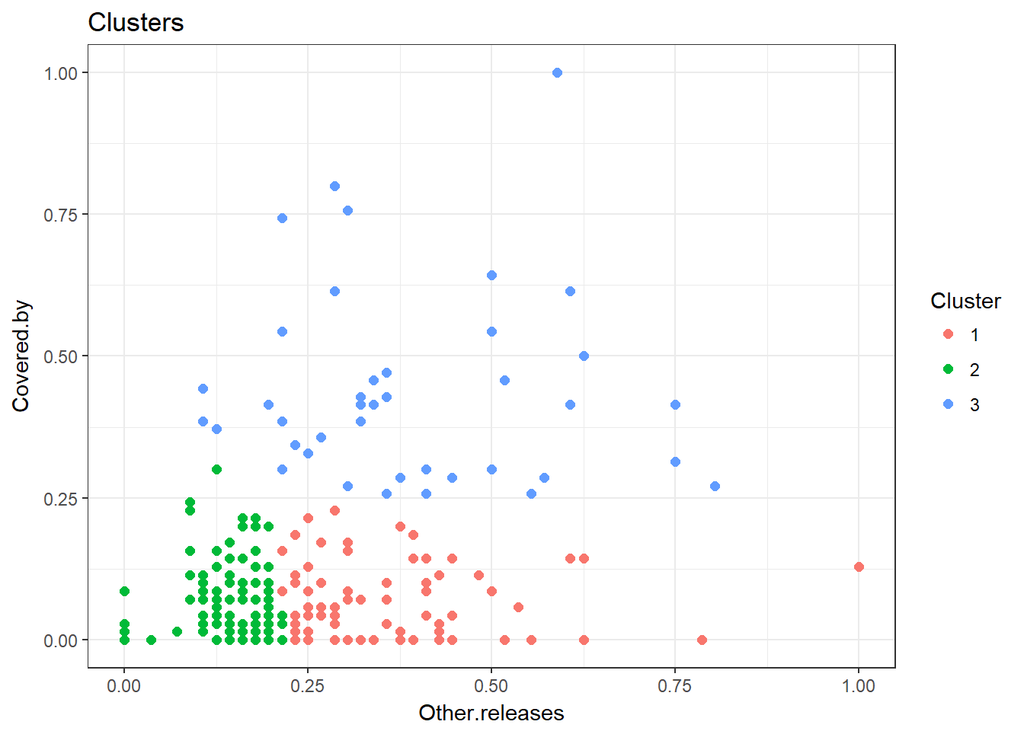

```r
scatterplot2 <- ggplot(the.beatles.songs.2,
                       aes(x = Other.releases, y = Covered.by,
                           colour = Cluster))
scatterplot2 <- scatterplot2 + geom_point(size = 2)
scatterplot2 <- scatterplot2 + xlab("Other.releases")
scatterplot2 <- scatterplot2 + ylab("Covered.by")
scatterplot2 <- scatterplot2 + ggtitle("Clusters")
scatterplot2 <- scatterplot2 +
  scale_fill_brewer(palette = "Set1", name = "Cluster")
scatterplot2 <- scatterplot2 + theme_bw()
scatterplot2
```

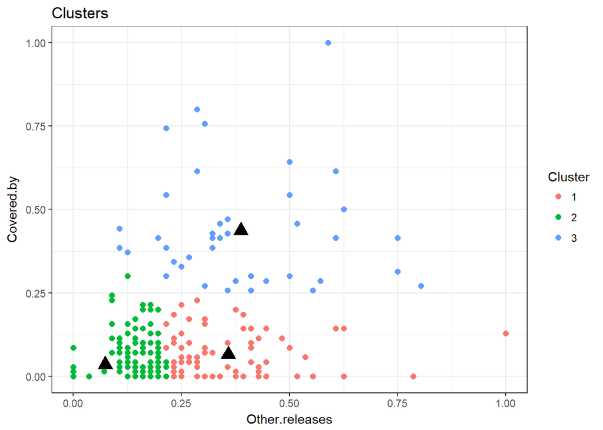

```r
scatterplot2 + geom_point(data = as.data.frame(clusters.K3$centers),  # add cluster centers
             color = "black",
             fill = "black",
             size = 4,
             shape = 24)
```

## Resources, readings, references

The corrplot package: https://cran.r-project.org/web/packages/corrplot/vignettes/corrplot-intro.html  
Understanding Diagnostic Plots for Linear Regression Analysis: http://data.library.virginia.edu/diagnostic-plots/